# Importing Libraries

```python
import pandas as pd
import numpy as np
import seaborn as sns
import matplotlib.pyplot as plt
import warnings
warnings.filterwarnings("ignore")
pd.set_option('display.max_columns',None)
pd.set_option('display.max_rows',None)
from sklearn.preprocessing import OneHotEncoder
from sklearn.preprocessing import MinMaxScaler
from sklearn.preprocessing import LabelEncoder
from sklearn.model_selection import train_test_split
from sklearn.metrics import accuracy_score, precision_score, recall_score, f1_score, roc_auc_score
from sklearn.linear_model import LogisticRegression
from sklearn.tree import DecisionTreeClassifier
from sklearn.ensemble import RandomForestClassifier, GradientBoostingClassifier, AdaBoostClassifier
from sklearn.svm import SVC
from sklearn.naive_bayes import GaussianNB
from sklearn.neighbors import KNeighborsClassifier
from sklearn.neural_network import MLPClassifier
from sklearn.model_selection import cross_val_score
from sklearn.metrics import confusion_matrix, classification_report, accuracy_score
from sklearn.metrics import roc_curve, auc
from sklearn.decomposition import PCA
```

# Data Loading and Initial Exploration

```python
df=pd.read_csv(r"C:\Users\saisu\OneDrive\Desktop\Predicting Airline Passenger Satisfaction Using Machine Learning\Data.csv")
```

```python
df.head()
```

|  | ID | Gender | Age | Customer Type | Type of Travel | Class | Flight Distance | Departure Delay | Arrival Delay | Departure and Arrival Time Convenience | Ease of Online Booking | Check-in Service | Online Boarding | Gate Location | On-board Service | Seat Comfort | Leg Room Service | Cleanliness | Food and Drink | In-flight Service | In-flight Wifi Service | In-flight Entertainment | Baggage Handling | Satisfaction |
| --- | --- | --- | --- | --- | --- | --- | --- | --- | --- | --- | --- | --- | --- | --- | --- | --- | --- | --- | --- | --- | --- | --- | --- | --- |
| 0 | 1 | Male | 48 | First-time | Business | Business | 821 | 2 | 5.0 | 3 | 3 | 4 | 3 | 3 | 3 | 5 | 2 | 5 | 5 | 5 | 3 | 5 | 5 | Neutral or Dissatisfied |
| 1 | 2 | Female | 35 | Returning | Business | Business | 821 | 26 | 39.0 | 2 | 2 | 3 | 5 | 2 | 5 | 4 | 5 | 5 | 3 | 5 | 2 | 5 | 5 | Satisfied |
| 2 | 3 | Male | 41 | Returning | Business | Business | 853 | 0 | 0.0 | 4 | 4 | 4 | 5 | 4 | 3 | 5 | 3 | 5 | 5 | 3 | 4 | 3 | 3 | Satisfied |
| 3 | 4 | Male | 50 | Returning | Business | Business | 1905 | 0 | 0.0 | 2 | 2 | 3 | 4 | 2 | 5 | 5 | 5 | 4 | 4 | 5 | 2 | 5 | 5 | Satisfied |
| 4 | 5 | Female | 49 | Returning | Business | Business | 3470 | 0 | 1.0 | 3 | 3 | 3 | 5 | 3 | 3 | 4 | 4 | 5 | 4 | 3 | 3 | 3 | 3 | Satisfied |

```python
df.shape
```

```
(129880, 24)
```

```python
df.info()
```

```
<class 'pandas.core.frame.DataFrame'>
RangeIndex: 129880 entries, 0 to 129879
Data columns (total 24 columns):
 #   Column                                  Non-Null Count   Dtype
---  ------                                  --------------   -----
 0   ID                                      129880 non-null  int64
 1   Gender                                  129880 non-null  object
 2   Age                                     129880 non-null  int64
 3   Customer Type                           129880 non-null  object
 4   Type of Travel                          129880 non-null  object
 5   Class                                   129880 non-null  object
 6   Flight Distance                         129880 non-null  object
 7   Departure Delay                         129880 non-null  int64
 8   Arrival Delay                           129487 non-null  float64
 9   Departure and Arrival Time Convenience  129880 non-null  int64
```

[output cut: 16 more lines]

```python
print(f'Null Values in Arrival Delay Column is {df["Arrival Delay"].isnull().sum()} means {round(df["Arrival Delay"].isnull().mean()*100,2)}% ')
```

```
Null Values in Arrival Delay Column is 393 means 0.3%
```

```python
df["Arrival Delay"].min()
```

```
np.float64(0.0)
```

```python
df.duplicated().sum()
```

```
np.int64(0)
```

```python
df.describe()
```

|  | ID | Age | Departure Delay | Arrival Delay | Departure and Arrival Time Convenience | Ease of Online Booking | Check-in Service | Online Boarding | Gate Location | On-board Service | Seat Comfort | Leg Room Service | Cleanliness | Food and Drink | In-flight Service | In-flight Wifi Service | In-flight Entertainment | Baggage Handling |
| --- | --- | --- | --- | --- | --- | --- | --- | --- | --- | --- | --- | --- | --- | --- | --- | --- | --- | --- |
| count | 129880.000000 | 129880.000000 | 129880.000000 | 129487.000000 | 129880.000000 | 129880.000000 | 129880.000000 | 129880.000000 | 129880.000000 | 129880.000000 | 129880.000000 | 129880.000000 | 129880.000000 | 129880.000000 | 129880.000000 | 129880.000000 | 129880.000000 | 129880.000000 |
| mean | 64940.500000 | 39.427957 | 14.713713 | 15.091129 | 3.057599 | 2.756876 | 3.306267 | 3.252633 | 2.976925 | 3.383023 | 3.441361 | 3.350878 | 3.286326 | 3.204774 | 3.642193 | 2.728696 | 3.358077 | 3.632114 |
| std | 37493.270818 | 15.119360 | 38.071126 | 38.465650 | 1.526741 | 1.401740 | 1.266185 | 1.350719 | 1.278520 | 1.287099 | 1.319289 | 1.316252 | 1.313682 | 1.329933 | 1.176669 | 1.329340 | 1.334049 | 1.180025 |
| min | 1.000000 | 7.000000 | 0.000000 | 0.000000 | 0.000000 | 0.000000 | 0.000000 | 0.000000 | 0.000000 | 0.000000 | 0.000000 | 0.000000 | 0.000000 | 0.000000 | 0.000000 | 0.000000 | 0.000000 | 1.000000 |
| 25% | 32470.750000 | 27.000000 | 0.000000 | 0.000000 | 2.000000 | 2.000000 | 3.000000 | 2.000000 | 2.000000 | 2.000000 | 2.000000 | 2.000000 | 2.000000 | 2.000000 | 3.000000 | 2.000000 | 2.000000 | 3.000000 |
| 50% | 64940.500000 | 40.000000 | 0.000000 | 0.000000 | 3.000000 | 3.000000 | 3.000000 | 3.000000 | 3.000000 | 4.000000 | 4.000000 | 4.000000 | 3.000000 | 3.000000 | 4.000000 | 3.000000 | 4.000000 | 4.000000 |
| 75% | 97410.250000 | 51.000000 | 12.000000 | 13.000000 | 4.000000 | 4.000000 | 4.000000 | 4.000000 | 4.000000 | 4.000000 | 5.000000 | 4.000000 | 4.000000 | 4.000000 | 5.000000 | 4.000000 | 4.000000 | 5.000000 |
| max | 129880.000000 | 85.000000 | 1592.000000 | 1584.000000 | 5.000000 | 5.000000 | 5.000000 | 5.000000 | 5.000000 | 5.000000 | 5.000000 | 5.000000 | 5.000000 | 5.000000 | 5.000000 | 5.000000 | 5.000000 | 5.000000 |

# **Data Cleaning**

- The `ID` column was dropped because it is a unique identifier and does not contribute to the analysis or model building.

```python
df=df.drop(columns=["ID"],axis=1)
```

- The `Flight Distance` column was originally of type `object`. This step converts it to a numeric type (`float64`), handling any non-numeric values using the `errors="coerce"` parameter, which replaces invalid values with `NaN`.
- This ensures that the column can be used for numerical analysis and modeling.

```python
df["Flight Distance"].dtypes
```

```
dtype('O')
```

```python
df["Flight Distance"]=pd.to_numeric(df["Flight Distance"],errors="coerce")
```

```python
df["Flight Distance"].dtypes
```

```
dtype('float64')
```

```python
df[["Arrival Delay","Flight Distance"]].isna().mean()*100
```

```
Arrival Delay      0.302587
Flight Distance    0.002310
dtype: float64
```

```python
df=df.dropna()
```

```python
df[["Arrival Delay","Flight Distance"]].isna().mean()*100
```

```
Arrival Delay      0.0
Flight Distance    0.0
dtype: float64
```

- In this case, columns such as **`Departure Delay`**, **`Arrival Delay`**, and **`Flight Distance`** have extreme values (high max values) compared to the **75th percentile** or **mean**. These indicate potential outliers.

```python
df.describe()
```

|  | Age | Flight Distance | Departure Delay | Arrival Delay | Departure and Arrival Time Convenience | Ease of Online Booking | Check-in Service | Online Boarding | Gate Location | On-board Service | Seat Comfort | Leg Room Service | Cleanliness | Food and Drink | In-flight Service | In-flight Wifi Service | In-flight Entertainment | Baggage Handling |
| --- | --- | --- | --- | --- | --- | --- | --- | --- | --- | --- | --- | --- | --- | --- | --- | --- | --- | --- |
| count | 129484.000000 | 129484.000000 | 129484.000000 | 129484.000000 | 129484.000000 | 129484.000000 | 129484.000000 | 129484.000000 | 129484.000000 | 129484.000000 | 129484.000000 | 129484.000000 | 129484.000000 | 129484.000000 | 129484.000000 | 129484.000000 | 129484.000000 | 129484.000000 |
| mean | 39.428810 | 1190.206504 | 14.642967 | 15.090451 | 3.057358 | 2.756812 | 3.306239 | 3.252742 | 2.976924 | 3.383221 | 3.441607 | 3.351101 | 3.286244 | 3.204720 | 3.642388 | 2.728577 | 3.358091 | 3.631924 |
| std | 15.117637 | 997.541811 | 37.933027 | 38.465538 | 1.526792 | 1.401661 | 1.266159 | 1.350652 | 1.278509 | 1.287041 | 1.319176 | 1.316136 | 1.313629 | 1.329898 | 1.176617 | 1.329231 | 1.334154 | 1.180063 |
| min | 7.000000 | 31.000000 | 0.000000 | 0.000000 | 0.000000 | 0.000000 | 0.000000 | 0.000000 | 0.000000 | 0.000000 | 0.000000 | 0.000000 | 0.000000 | 0.000000 | 0.000000 | 0.000000 | 0.000000 | 1.000000 |
| 25% | 27.000000 | 414.000000 | 0.000000 | 0.000000 | 2.000000 | 2.000000 | 3.000000 | 2.000000 | 2.000000 | 2.000000 | 2.000000 | 2.000000 | 2.000000 | 2.000000 | 3.000000 | 2.000000 | 2.000000 | 3.000000 |
| 50% | 40.000000 | 844.000000 | 0.000000 | 0.000000 | 3.000000 | 3.000000 | 3.000000 | 3.000000 | 3.000000 | 4.000000 | 4.000000 | 4.000000 | 3.000000 | 3.000000 | 4.000000 | 3.000000 | 4.000000 | 4.000000 |
| 75% | 51.000000 | 1744.000000 | 12.000000 | 13.000000 | 4.000000 | 4.000000 | 4.000000 | 4.000000 | 4.000000 | 4.000000 | 5.000000 | 4.000000 | 4.000000 | 4.000000 | 5.000000 | 4.000000 | 4.000000 | 5.000000 |
| max | 85.000000 | 4983.000000 | 1592.000000 | 1584.000000 | 5.000000 | 5.000000 | 5.000000 | 5.000000 | 5.000000 | 5.000000 | 5.000000 | 5.000000 | 5.000000 | 5.000000 | 5.000000 | 5.000000 | 5.000000 | 5.000000 |

- For the columns **`Flight Distance`**, **`Departure Delay`**, and **`Arrival Delay`**, the **IQR method** was used to detect and handle outliers.
- The **IQR** is calculated by finding the 25th percentile (Q1) and the 75th percentile (Q3), then determining the **lower bound** and **upper bound** as follows:
  - **Lower bound**: `Q1 - 1.5 * IQR`
  - **Upper bound**: `Q3 + 1.5 * IQR`
- Values below the **lower bound** are replaced with the lower bound, and values above the **upper bound** are replaced with the upper bound, thus capping the outliers.

```python
for i in ["Flight Distance","Departure Delay","Arrival Delay"]:
    Q1 = df[i].quantile(0.25)
    Q3 = df[i].quantile(0.75)
    IQR = Q3 - Q1
    lower_bound = Q1 - 1.5 * IQR
    upper_bound = Q3 + 1.5 * IQR

    # Correct lambda without nesting
    df[i] = df[i].apply(lambda x: upper_bound if x > upper_bound else (lower_bound if x < lower_bound else x))


    df[i] = pd.to_numeric(df[i])
```

```python
df.describe()
```

|  | Age | Flight Distance | Departure Delay | Arrival Delay | Departure and Arrival Time Convenience | Ease of Online Booking | Check-in Service | Online Boarding | Gate Location | On-board Service | Seat Comfort | Leg Room Service | Cleanliness | Food and Drink | In-flight Service | In-flight Wifi Service | In-flight Entertainment | Baggage Handling |
| --- | --- | --- | --- | --- | --- | --- | --- | --- | --- | --- | --- | --- | --- | --- | --- | --- | --- | --- |
| count | 129484.000000 | 129484.000000 | 129484.000000 | 129484.000000 | 129484.000000 | 129484.000000 | 129484.000000 | 129484.000000 | 129484.000000 | 129484.000000 | 129484.000000 | 129484.000000 | 129484.000000 | 129484.000000 | 129484.000000 | 129484.000000 | 129484.000000 | 129484.000000 |
| mean | 39.428810 | 1186.881568 | 7.362315 | 7.933073 | 3.057358 | 2.756812 | 3.306239 | 3.252742 | 2.976924 | 3.383221 | 3.441607 | 3.351101 | 3.286244 | 3.204720 | 3.642388 | 2.728577 | 3.358091 | 3.631924 |
| std | 15.117637 | 988.472484 | 11.197156 | 11.981089 | 1.526792 | 1.401661 | 1.266159 | 1.350652 | 1.278509 | 1.287041 | 1.319176 | 1.316136 | 1.313629 | 1.329898 | 1.176617 | 1.329231 | 1.334154 | 1.180063 |
| min | 7.000000 | 31.000000 | 0.000000 | 0.000000 | 0.000000 | 0.000000 | 0.000000 | 0.000000 | 0.000000 | 0.000000 | 0.000000 | 0.000000 | 0.000000 | 0.000000 | 0.000000 | 0.000000 | 0.000000 | 1.000000 |
| 25% | 27.000000 | 414.000000 | 0.000000 | 0.000000 | 2.000000 | 2.000000 | 3.000000 | 2.000000 | 2.000000 | 2.000000 | 2.000000 | 2.000000 | 2.000000 | 2.000000 | 3.000000 | 2.000000 | 2.000000 | 3.000000 |
| 50% | 40.000000 | 844.000000 | 0.000000 | 0.000000 | 3.000000 | 3.000000 | 3.000000 | 3.000000 | 3.000000 | 4.000000 | 4.000000 | 4.000000 | 3.000000 | 3.000000 | 4.000000 | 3.000000 | 4.000000 | 4.000000 |
| 75% | 51.000000 | 1744.000000 | 12.000000 | 13.000000 | 4.000000 | 4.000000 | 4.000000 | 4.000000 | 4.000000 | 4.000000 | 5.000000 | 4.000000 | 4.000000 | 4.000000 | 5.000000 | 4.000000 | 4.000000 | 5.000000 |
| max | 85.000000 | 3739.000000 | 30.000000 | 32.500000 | 5.000000 | 5.000000 | 5.000000 | 5.000000 | 5.000000 | 5.000000 | 5.000000 | 5.000000 | 5.000000 | 5.000000 | 5.000000 | 5.000000 | 5.000000 | 5.000000 |

- `Num`: Contains all **numerical columns**
- `Cat`: Includes selected **categorical features**
- `Target`: Consists of the **target variable**
- This separation is useful for applying different preprocessing and analysis techniques based on feature types.

```python
Num=df[df.describe().keys()]
Cat=df[["Gender","Customer Type","Type of Travel","Class"]]
Target=df[["Satisfaction"]]
```

- This matrix helps in:
  - Identifying **strong relationships** between numerical features.
  - Detecting **multicollinearity**, which may affect model performance.
  - Understanding which features might be most relevant to the target or redundant due to high inter-correlation.

```python
Num.corr()
```

|  | Age | Flight Distance | Departure Delay | Arrival Delay | Departure and Arrival Time Convenience | Ease of Online Booking | Check-in Service | Online Boarding | Gate Location | On-board Service | Seat Comfort | Leg Room Service | Cleanliness | Food and Drink | In-flight Service | In-flight Wifi Service | In-flight Entertainment | Baggage Handling |
| --- | --- | --- | --- | --- | --- | --- | --- | --- | --- | --- | --- | --- | --- | --- | --- | --- | --- | --- |
| Age | 1.000000 | 0.099988 | -0.007894 | -0.010941 | 0.036784 | 0.022280 | 0.033183 | 0.207475 | -0.000712 | 0.056749 | 0.159223 | 0.038991 | 0.052567 | 0.023280 | -0.051767 | 0.015769 | 0.074989 | -0.048192 |
| Flight Distance | 0.099988 | 1.000000 | 0.000636 | -0.007138 | -0.018767 | 0.065290 | 0.073950 | 0.215750 | 0.005406 | 0.111666 | 0.158388 | 0.134856 | 0.096004 | 0.057404 | 0.059543 | 0.006663 | 0.130899 | 0.065004 |
| Departure Delay | -0.007894 | 0.000636 | 1.000000 | 0.841516 | -0.001394 | -0.006878 | -0.024870 | -0.030997 | 0.006613 | -0.032922 | -0.026116 | -0.006767 | -0.021992 | -0.024959 | -0.037960 | -0.025939 | -0.030914 | -0.016778 |
| Arrival Delay | -0.010941 | -0.007138 | 0.841516 | 1.000000 | -0.002412 | -0.009437 | -0.035415 | -0.042187 | 0.007476 | -0.045959 | -0.036313 | -0.016167 | -0.031709 | -0.032961 | -0.053910 | -0.030560 | -0.041787 | -0.028783 |
| Departure and Arrival Time Convenience | 0.036784 | -0.018767 | -0.001394 | -0.002412 | 1.000000 | 0.437699 | 0.091225 | 0.072183 | 0.447403 | 0.067045 | 0.008709 | 0.010636 | 0.010016 | 0.001044 | 0.072159 | 0.344846 | -0.008188 | 0.070627 |
| Ease of Online Booking | 0.022280 | 0.065290 | -0.006878 | -0.009437 | 0.437699 | 1.000000 | 0.008839 | 0.404936 | 0.460150 | 0.039036 | 0.028589 | 0.109332 | 0.015131 | 0.030615 | 0.035356 | 0.714883 | 0.046659 | 0.039191 |
| Check-in Service | 0.033183 | 0.073950 | -0.024870 | -0.035415 | 0.091225 | 0.008839 | 1.000000 | 0.204214 | -0.039288 | 0.244620 | 0.189838 | 0.152713 | 0.176615 | 0.085108 | 0.237740 | 0.043849 | 0.119662 | 0.234745 |
| Online Boarding | 0.207475 | 0.215750 | -0.030997 | -0.042187 | 0.072183 | 0.404936 | 0.204214 | 1.000000 | 0.002577 | 0.154269 | 0.419161 | 0.123136 | 0.329323 | 0.233516 | 0.073975 | 0.457414 | 0.283999 | 0.083554 |
| Gate Location | -0.000712 | 0.005406 | 0.006613 | 0.007476 | 0.447403 | 0.460150 | -0.039288 | 0.002577 | 1.000000 | -0.029113 | 0.002489 | -0.005149 | -0.006078 | -0.002845 | 0.000331 | 0.338540 | 0.002748 | 0.001071 |
| On-board Service | 0.056749 | 0.111666 | -0.032922 | -0.045959 | 0.067045 | 0.039036 | 0.244620 | 0.154269 | -0.029113 | 1.000000 | 0.130649 | 0.357870 | 0.122203 | 0.057464 | 0.551455 | 0.120020 | 0.418857 | 0.520399 |
| Seat Comfort | 0.159223 | 0.158388 | -0.026116 | -0.036313 | 0.008709 | 0.028589 | 0.189838 | 0.419161 | 0.002489 | 0.130649 | 1.000000 | 0.104233 | 0.679654 | 0.575992 | 0.068911 | 0.121359 | 0.611946 | 0.074605 |
| Leg Room Service | 0.038991 | 0.134856 | -0.006767 | -0.016167 | 0.010636 | 0.109332 | 0.152713 | 0.123136 | -0.005149 | 0.357870 | 0.104233 | 1.000000 | 0.096767 | 0.033198 | 0.369830 | 0.160400 | 0.300561 | 0.371593 |
| Cleanliness | 0.052567 | 0.096004 | -0.021992 | -0.031709 | 0.010016 | 0.015131 | 0.176615 | 0.329323 | -0.006078 | 0.122203 | 0.679654 | 0.096767 | 1.000000 | 0.658021 | 0.090562 | 0.131146 | 0.692491 | 0.097087 |
| Food and Drink | 0.023280 | 0.057404 | -0.024959 | -0.032961 | 0.001044 | 0.030615 | 0.085108 | 0.233516 | -0.002845 | 0.057464 | 0.575992 | 0.033198 | 0.658021 | 1.000000 | 0.035410 | 0.132083 | 0.623364 | 0.035373 |
| In-flight Service | -0.051767 | 0.059543 | -0.037960 | -0.053910 | 0.072159 | 0.035356 | 0.237740 | 0.073975 | 0.000331 | 0.551455 | 0.068911 | 0.369830 | 0.090562 | 0.035410 | 1.000000 | 0.110294 | 0.406558 | 0.629492 |
| In-flight Wifi Service | 0.015769 | 0.006663 | -0.025939 | -0.030560 | 0.344846 | 0.714883 | 0.043849 | 0.457414 | 0.338540 | 0.120020 | 0.121359 | 0.160400 | 0.131146 | 0.132083 | 0.110294 | 1.000000 | 0.207874 | 0.120519 |
| In-flight Entertainment | 0.074989 | 0.130899 | -0.030914 | -0.041787 | -0.008188 | 0.046659 | 0.119662 | 0.283999 | 0.002748 | 0.418857 | 0.611946 | 0.300561 | 0.692491 | 0.623364 | 0.406558 | 0.207874 | 1.000000 | 0.379285 |
| Baggage Handling | -0.048192 | 0.065004 | -0.016778 | -0.028783 | 0.070627 | 0.039191 | 0.234745 | 0.083554 | 0.001071 | 0.520399 | 0.074605 | 0.371593 | 0.097087 | 0.035373 | 0.629492 | 0.120519 | 0.379285 | 1.000000 |

## Observations from Correlation Matrix

1. **Delays are Strongly Related**:
   - `Departure Delay` and `Arrival Delay` have a very high positive correlation (**0.84**), indicating that if a flight departs late, it is very likely to arrive late.
2. **In-flight Experience Features are Interconnected**:
   - Features like `Seat Comfort`, `Cleanliness`, `Food and Drink`, and `In-flight Entertainment` show **moderate to strong positive correlations** with each other, suggesting that better in-flight experience tends to be consistently rated across multiple aspects.
3. **Online Services are Interrelated**:
   - `Ease of Online Booking`, `Online Boarding`, and `In-flight Wifi Service` are positively correlated, reflecting a pattern that customers who use or like one online service often rate others positively too.
4. **Flight Distance Has Weak Correlation**:
   - `Flight Distance` does not show strong correlation with delays or service quality features, suggesting it might be independent of perceived service or punctuality.
5. **Age Has Weak to Moderate Correlation**:
   - `Age` has weak to moderate positive correlation with `Online Boarding` and `Seat Comfort`, which might suggest older passengers tend to rate some services slightly higher.
6. **Gate Location is Largely Unrelated**:
   - `Gate Location` shows minimal or near-zero correlation with most other features, implying it's perceived independently by passengers.
- **Dropped the `Departure Delay` column**: The column `Departure Delay` is removed from the numerical feature set (`Num`) to reduce multicollinearity, as it is highly correlated with `Arrival Delay`. This helps improve model performance by preventing redundancy.
- **Reduced dimensionality**: By removing `Departure Delay`, the dimensionality of the dataset is reduced, simplifying the model and improving interpretability without losing significant information, as `Arrival Delay` is retained.

```python
Num=Num.drop(columns=["Departure Delay"],axis=1)
```

# Data Visualisation

```python
Target["Satisfaction"].value_counts()
```

```
Satisfaction
Neutral or Dissatisfied    73222
Satisfied                  56262
Name: count, dtype: int64
```

```python
for i in df.keys():
  print(f"No of Unique Values in {i} are {df[i].nunique()} And  They are \n {df[i].unique()}")
```

```
No of Unique Values in Gender are 2 And  They are
 ['Male' 'Female']
No of Unique Values in Age are 75 And  They are
 [48 35 41 50 49 43 60 38 28 27 24  9 52 70 61 11 42 14 56 77 51 47 58 40
 21 33 39 54 46 45 23 20 44 37 57 31 36 53 25 55 72 19 65 32 80  7 34 18
 12 26 17 66 68 67 59 69 16 64 29 10 71 22 30 62 63  8 15 73 78 74 79 13
 76 75 85]
No of Unique Values in Customer Type are 2 And  They are
 ['First-time' 'Returning']
No of Unique Values in Type of Travel are 2 And  They are
 ['Business' 'Personal']
No of Unique Values in Class are 3 And  They are
 ['Business' 'Economy' 'Economy Plus']
No of Unique Values in Flight Distance are 3555 And  They are
 [ 821.  853. 1905. ... 1019. 1161. 1051.]
No of Unique Values in Departure Delay are 31 And  They are
 [ 2. 26.  0. 13. 20. 16. 30.  4. 12.  6. 22. 23. 29.  1. 19.  7. 10. 18.
 27. 11.  3. 15. 21. 17.  9. 25. 14.  5. 24.  8. 28.]
No of Unique Values in Arrival Delay are 34 And  They are
 [ 5.  32.5  0.   1.   3.  21.  30.   2.  15.  24.  12.  28.  17.  26.
  8.  14.  13.  29.  10.   4.   7.  11.  18.  27.  25.   6.  16.  19.
  9.  31.  22.  32.  23.  20. ]
No of Unique Values in Departure and Arrival Time Convenience are 6 And  They are
 [3 2 4 1 5 0]
No of Unique Values in Ease of Online Booking are 6 And  They are
 [3 2 4 1 5 0]
No of Unique Values in Check-in Service are 6 And  They are
 [4 3 1 2 5 0]
No of Unique Values in Online Boarding are 6 And  They are
 [3 5 4 2 1 0]
No of Unique Values in Gate Location are 6 And  They are
 [3 2 4 1 5 0]
No of Unique Values in On-board Service are 6 And  They are
 [3 5 4 2 1 0]
No of Unique Values in Seat Comfort are 6 And  They are
 [5 4 3 2 1 0]
No of Unique Values in Leg Room Service are 6 And  They are
 [2 5 3 4 1 0]
No of Unique Values in Cleanliness are 6 And  They are
 [5 4 3 2 1 0]
No of Unique Values in Food and Drink are 6 And  They are
 [5 3 4 2 1 0]
No of Unique Values in In-flight Service are 6 And  They are
 [5 3 4 1 2 0]
No of Unique Values in In-flight Wifi Service are 6 And  They are
 [3 2 4 1 0 5]
No of Unique Values in In-flight Entertainment are 6 And  They are
 [5 3 4 2 1 0]
No of Unique Values in Baggage Handling are 5 And  They are
 [5 3 4 1 2]
No of Unique Values in Satisfaction are 2 And  They are
 ['Neutral or Dissatisfied' 'Satisfied']
```

- Although columns like "Departure and Arrival Time Convenience," "Ease of Online Booking," and others contain numeric values, they have a limited number of unique values (e.g., 6 or 5). These columns should be treated as categorical variables instead of continuous numeric ones due to their discrete nature.

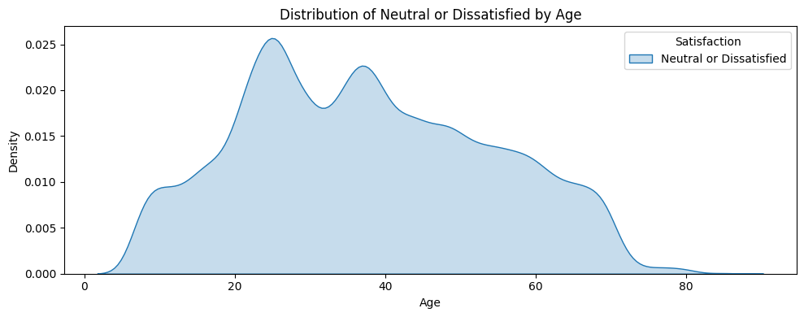

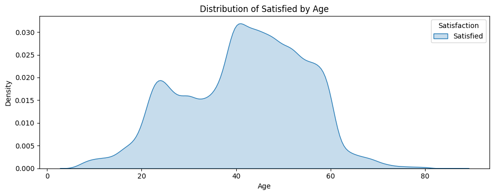

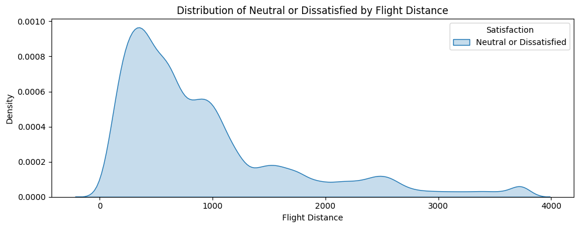

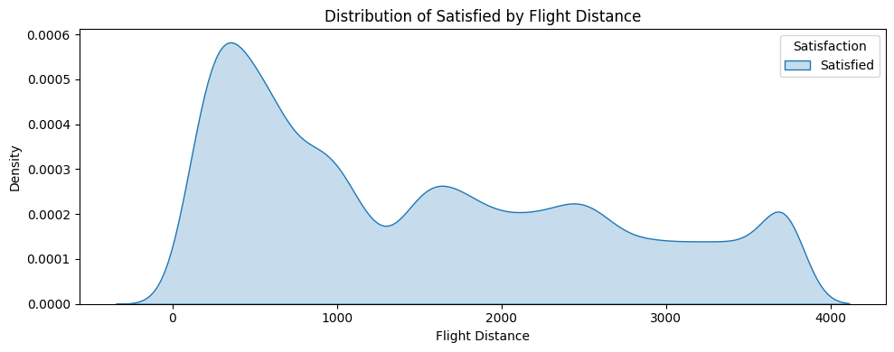

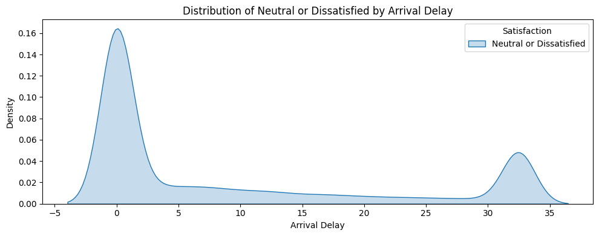

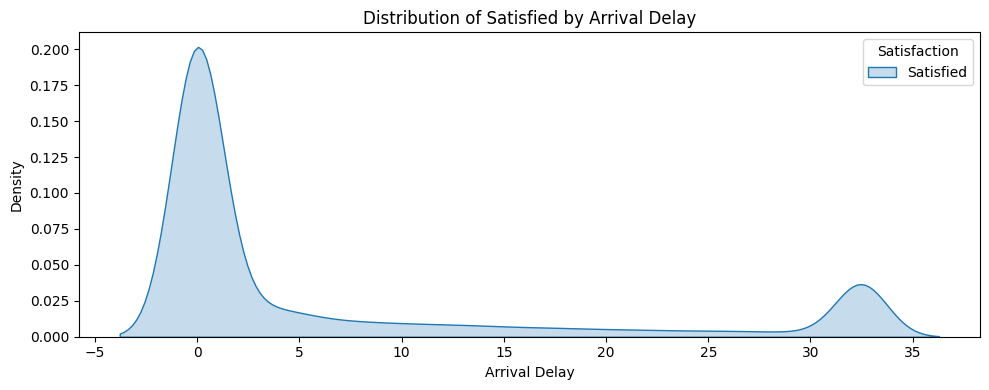

```python
for j in ["Age","Flight Distance","Arrival Delay"]:
  for i in Target['Satisfaction'].unique():
    plt.figure(figsize=(10, 4))
    sns.kdeplot(data=Num.join(Target), x=Num[j], hue=Target['Satisfaction'][Target['Satisfaction']==i], fill=True)
    plt.title(f'Distribution of {i} by {j}', fontsize=12)
    plt.xlabel(j, fontsize=10)
    plt.ylabel("Density", fontsize=10)
    plt.xticks(rotation=0, fontsize=10)
    plt.tight_layout()
    plt.show()
    print("\n\n")
```

## Observations

- **Neutral or Dissatisfied by Age:** The distribution of neutral or dissatisfied customers is concentrated mostly between the ages of 20 to 60 years.
- **Neutral or Dissatisfied by Flight Distance:** The distribution shows that most neutral or dissatisfied customers have flight distances ranging from 0 to around 2000 miles.
- **Neutral or Dissatisfied by Arrival Delay:** The majority of neutral or dissatisfied customers experience arrival delays between 0 to 15 minutes, with a sudden spike observed between 30 to 35 minutes.
- **Satisfied by Flight Distance:** Satisfied customers are distributed across a wider range of flight distances, from 0 to 4000 miles.
- **Satisfied by Age:** The majority of satisfied customers are between the ages of 20 to 60 years.
- **Satisfied by Arrival Delay:** Most satisfied customers experience arrival delays between 0 to 10 minutes.

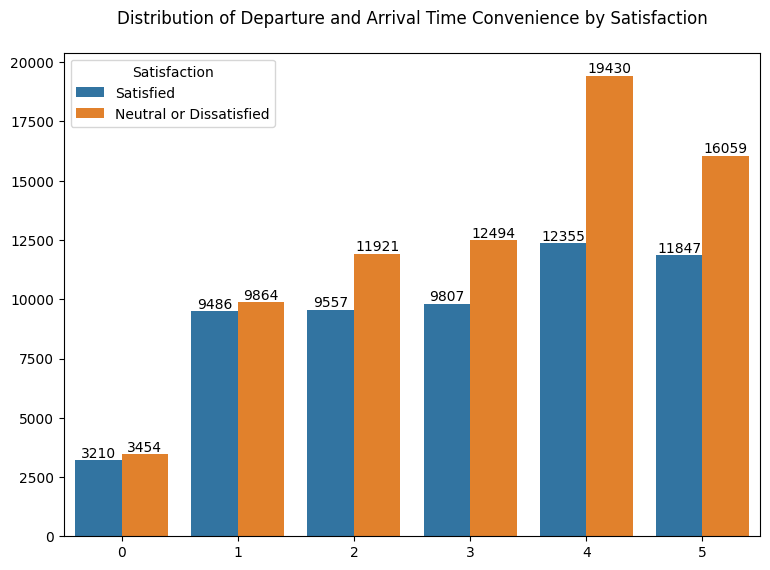

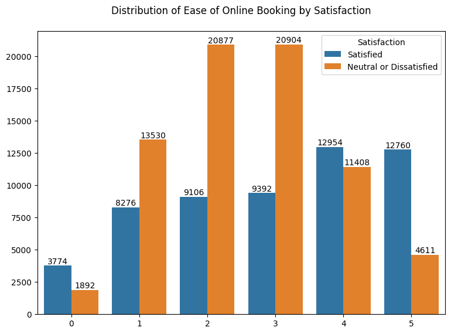

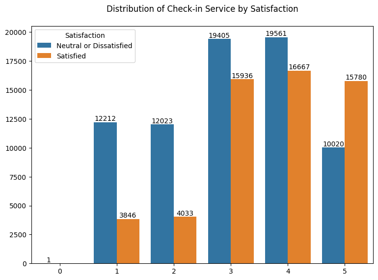

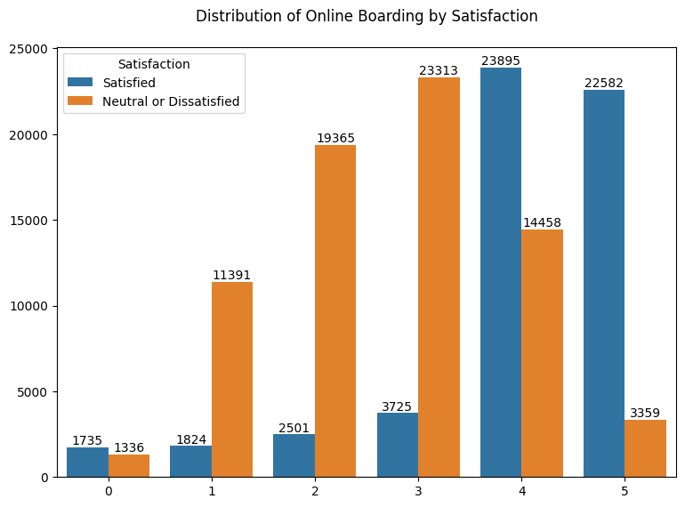

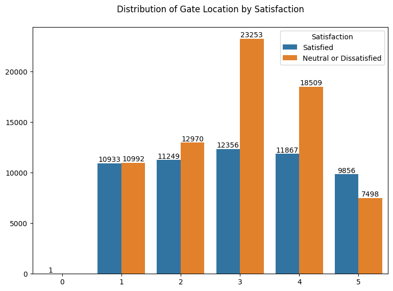

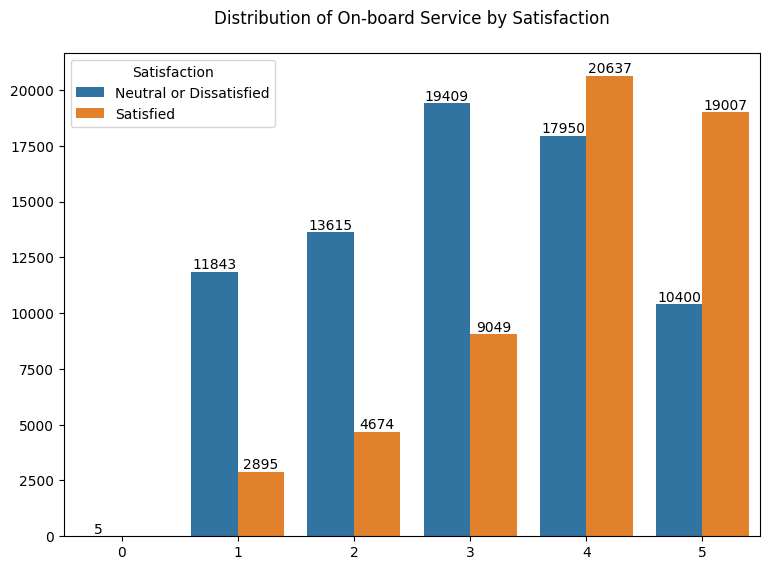

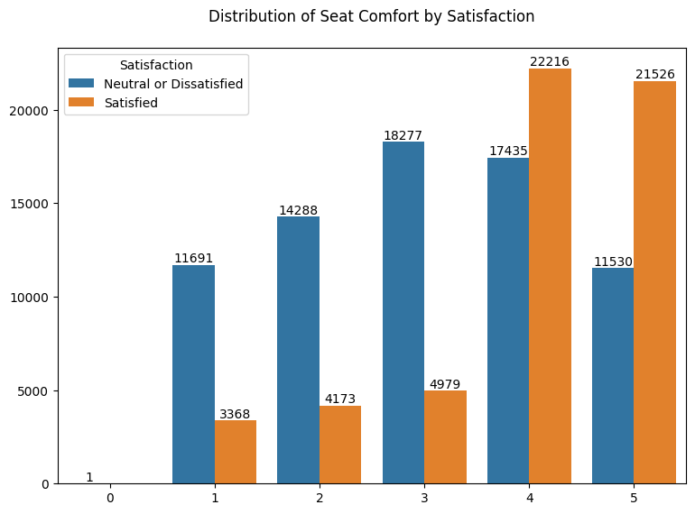

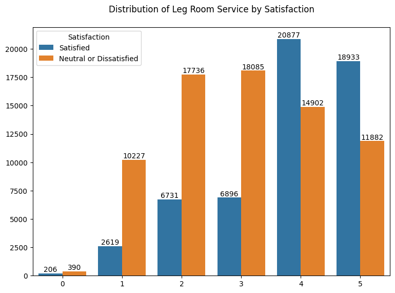

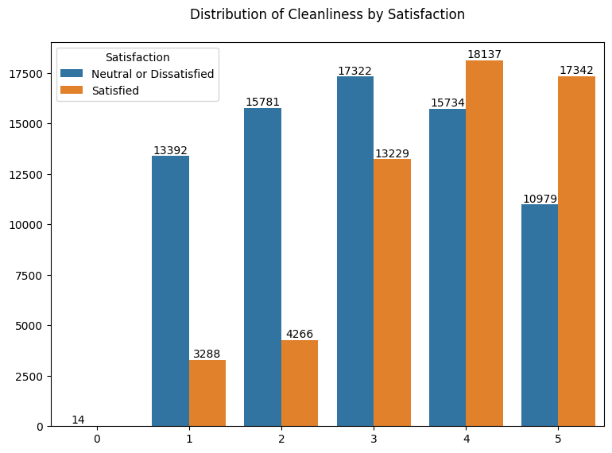

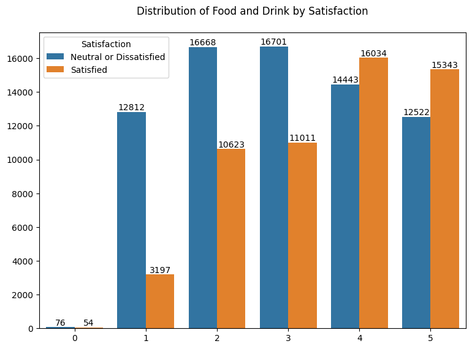

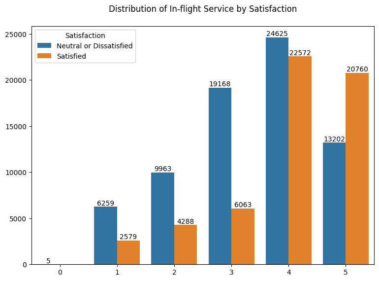

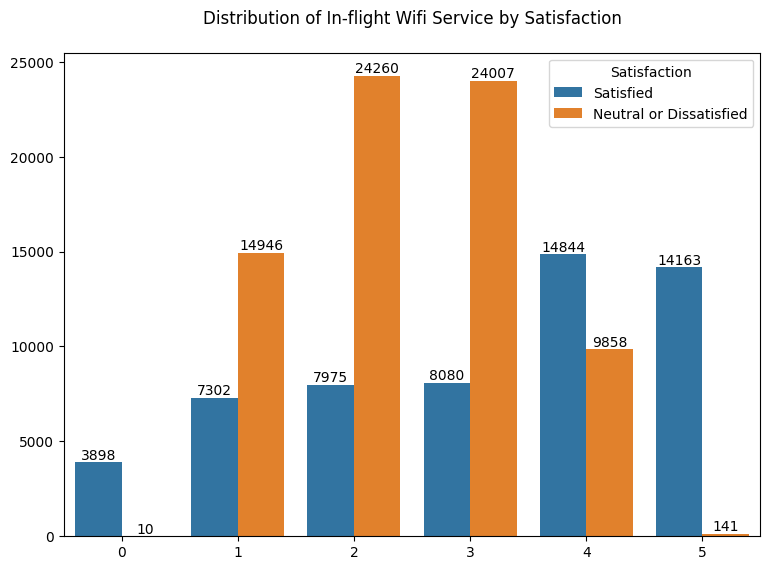

[6 more figures not shown]

```python
col= ['Departure and Arrival Time Convenience', 'Ease of Online Booking',
      'Check-in Service', 'Online Boarding', 'Gate Location', 'On-board Service',
      'Seat Comfort', 'Leg Room Service', 'Cleanliness', 'Food and Drink', 'In-flight Service',
      'In-flight Wifi Service', 'In-flight Entertainment', 'Baggage Handling', 'Gender', 'Customer Type', 'Type of Travel','Class']
for i in col:
  plt.figure(figsize=(8,6))
  ax=sns.countplot(x=df[i], hue=Target["Satisfaction"])
  for container in ax.containers:
      ax.bar_label(container, label_type='edge', fontsize=10)
  plt.title(f'Distribution of {i} by Satisfaction\n',fontsize=12)
  plt.tight_layout()
  plt.xticks(rotation=0,fontsize=10)
  plt.tight_layout()
  plt.xlabel(None)
  plt.ylabel(None)
  plt.show()
```

## Observations

#### 2. Ease of Online Booking:

- **Satisfied (ratings 4 & 5)**:
  - High satisfaction with ratings **5 (12,760)** and **4 (12,954)**.
- **Neutral/Dissatisfied (ratings 1, 2, 3)**:
  - High dissatisfaction in **2 (20,877)** and **3 (20,904)**, indicating areas for improvement.

#### 3. Check-in Service:

- **Satisfied (ratings 4 & 5)**:
  - Ratings **5 (15,780)** and **4 (16,667)** suggest high satisfaction with check-in services.
- **Neutral/Dissatisfied (ratings 1, 2, 3)**:
  - Significant dissatisfaction from **2 (12,023)** and **3 (19,405)**.

#### 4. Online Boarding:

- **Satisfied (ratings 4 & 5)**:
  - High satisfaction with **5 (22,582)** and **4 (23,895)**.
- **Neutral/Dissatisfied (ratings 1, 2, 3)**:
  - Dissatisfaction observed in **3 (23,313)** and **2 (19,365)**.

#### 5. Gate Location:

- **Satisfied (ratings 4 & 5)**:
  - Ratings **4 (11,867)** and **5 (9,856)** indicate general satisfaction with gate location.
- **Neutral/Dissatisfied (ratings 1, 2, 3)**:
  - Rating **3 (23,253)** shows noticeable dissatisfaction.

#### 7. Seat Comfort:

- **Satisfied (ratings 4 & 5)**:
  - Ratings **5 (21,526)** and **4 (22,216)** reflect strong satisfaction with seat comfort.
- **Neutral/Dissatisfied (ratings 1, 2, 3)**:
  - Rating **2 (14,288)** shows notable dissatisfaction.

#### 8. Leg Room Service:

- **Satisfied (ratings 4 & 5)**:
  - High satisfaction with **5 (18,933)** and **4 (20,877)**.
- **Neutral/Dissatisfied (ratings 1, 2, 3)**:
  - Dissatisfaction peaks at **2 (17,736)** and **3 (18,085)**.

#### 9. Cleanliness:

- **Satisfied (ratings 4 & 5)**:
  - Ratings **5 (17,342)** and **4 (18,137)** show satisfaction with cleanliness.
- **Neutral/Dissatisfied (ratings 1, 2, 3)**:
  - Dissatisfaction visible in **2 (15,781)**.

#### 10. Food and Drink:

- **Satisfied (ratings 4 & 5)**:
  - High satisfaction in ratings **5 (15,343)** and **4 (16,034)**.
- **Neutral/Dissatisfied (ratings 1, 2, 3)**:
  - Dissatisfaction noted in **2 (16,668)** and **3 (16,701)**.

#### 11. In-flight Service:

- **Satisfied (ratings 4 & 5)**:
  - High satisfaction with **5 (20,760)** and **4 (22,572)**.
- **Neutral/Dissatisfied (ratings 1, 2, 3)**:
  - Dissatisfaction seen in **3 (19,168)** and **2 (9,963)**.

#### 12. In-flight Wifi Service:

- **Satisfied (ratings 4 & 5)**:
  - High satisfaction with **5 (14,163)** and **4 (14,844)**.
- **Neutral/Dissatisfied (ratings 1, 2, 3)**:
  - Dissatisfaction peaks at **2 (24,260)** and **3 (24,007)**.

#### 13. In-flight Entertainment:

- **Satisfied (ratings 4 & 5)**:
  - Ratings **5 (20,462)** and **4 (22,429)** show general satisfaction with entertainment.
- **Neutral/Dissatisfied (ratings 1, 2, 3)**:
  - Dissatisfaction seen in **2 (17,238)** and **3 (17,310)**.

#### 14. Baggage Handling:

- **Satisfied (ratings 4 & 5)**:
  - Satisfaction levels high in **5 (20,796)** and **4 (22,417)**.
- **Neutral/Dissatisfied (ratings 1, 2, 3)**:
  - Significant dissatisfaction with **2 (10,099)** and **3 (19,641)**.

#### 15. Gender:

- **Satisfied**:
  - Females (**28,179**) and Males (**28,083**) show similar satisfaction levels.
- **Neutral/Dissatisfied**:
  - Females (**37,523**) show slightly higher dissatisfaction compared to males (**35,699**).

#### 16. Customer Type:

- **Satisfied**:
  - Returning customers (**50,574**) have higher satisfaction than first-time customers (**5,688**).
- **Neutral/Dissatisfied**:
  - Returning customers also report more dissatisfaction (**55,197**) than first-time customers (**18,025**).

#### 17. Type of Travel:

- **Satisfied**:
  - Business travelers (**52,207**) are more satisfied than personal travelers (**4,055**).
- **Neutral/Dissatisfied**:
  - Business travelers show higher dissatisfaction (**37,235**) compared to personal travelers (**35,987**).

#### 18. Class:

- **Satisfied**:
  - Business Class (**43,050**) are more satisfied than Economy (**10,902**) and Economy Plus (**2,310**) Classes
- **Neutral/Dissatisfied**:
  - Economy Class show higher dissatisfaction (**47,214**) compared to Business Class (**18,938**) and Economy Plus (**7,070**) Class

# Feature Engineering And Data Preprocessing

```python
encoder=OneHotEncoder(drop='first', sparse_output=False)
```

## Target

- Neutral or Dissatisfied : 0
- Satisfied : 1

```python
Target["Satisfaction"].unique()
```

[output not shown]

```python
enc=encoder.fit_transform(Target)
```

```python
Target=pd.DataFrame(enc,columns=Target.keys())
```

```python
Target.head()
```

|  | Satisfaction |
| --- | --- |
| 0 | 0.0 |
| 1 | 1.0 |
| 2 | 1.0 |
| 3 | 1.0 |
| 4 | 1.0 |

## Categorical Variables

#### Customer Type

- First-time : 0
- Returning : 1

#### Type of Travel

- Bussiness : 0
- Personal : 1

#### Class

- Economy : 0
- Economy Plus : 1
- Business : 2

```python
Cat_Enc=encoder.fit_transform(Cat[['Gender','Customer Type','Type of Travel']])
```

```python
Cat = pd.DataFrame(Cat_Enc, columns=['Gender','Customer Type','Type of Travel'])
```

```python
Cat["Class"] = df["Class"].apply(lambda x: 0 if x == "Economy" else (1 if x == "Economy Plus" else 2))
```

```python
Cat.head()
```

|  | Gender | Customer Type | Type of Travel | Class |
| --- | --- | --- | --- | --- |
| 0 | 1.0 | 0.0 | 0.0 | 2.0 |
| 1 | 0.0 | 1.0 | 0.0 | 2.0 |
| 2 | 1.0 | 1.0 | 0.0 | 2.0 |
| 3 | 1.0 | 1.0 | 0.0 | 2.0 |
| 4 | 0.0 | 1.0 | 0.0 | 2.0 |

## Numerical

- **Scaled only continuous numerical features**: `Age`, `Flight Distance`, and `Arrival Delay` were scaled using MinMaxScaler as they vary widely in range and are not bounded like ratings.
- **Skipped scaling for service rating features** like `Check-in Service`, `Food and Drink`, `Seat Comfort`, etc., as they already lie within a fixed 0–5 range and are ordinal in nature.

```python
Num1=Num[['Age', 'Flight Distance', 'Arrival Delay']]
Num2=Num.drop(columns=['Age', 'Flight Distance', 'Arrival Delay'],axis=1)
```

```python
scaler=MinMaxScaler()
```

```python
Num_Scaled=scaler.fit_transform(Num1)
```

```python
Num1=pd.DataFrame(Num_Scaled,columns=["Age Flight","Distance","Arrival Delay"])
```

```python
Num = pd.concat([Num1.reset_index(drop=True), Num2.reset_index(drop=True)], axis=1)
```

```python
Num.head()
```

|  | Age Flight | Distance | Arrival Delay | Departure and Arrival Time Convenience | Ease of Online Booking | Check-in Service | Online Boarding | Gate Location | On-board Service | Seat Comfort | Leg Room Service | Cleanliness | Food and Drink | In-flight Service | In-flight Wifi Service | In-flight Entertainment | Baggage Handling |
| --- | --- | --- | --- | --- | --- | --- | --- | --- | --- | --- | --- | --- | --- | --- | --- | --- | --- |
| 0 | 0.525641 | 0.213053 | 0.153846 | 3 | 3 | 4 | 3 | 3 | 3 | 5 | 2 | 5 | 5 | 5 | 3 | 5 | 5 |
| 1 | 0.358974 | 0.213053 | 1.000000 | 2 | 2 | 3 | 5 | 2 | 5 | 4 | 5 | 5 | 3 | 5 | 2 | 5 | 5 |
| 2 | 0.435897 | 0.221683 | 0.000000 | 4 | 4 | 4 | 5 | 4 | 3 | 5 | 3 | 5 | 5 | 3 | 4 | 3 | 3 |
| 3 | 0.551282 | 0.505394 | 0.000000 | 2 | 2 | 3 | 4 | 2 | 5 | 5 | 5 | 4 | 4 | 5 | 2 | 5 | 5 |
| 4 | 0.538462 | 0.927454 | 0.030769 | 3 | 3 | 3 | 5 | 3 | 3 | 4 | 4 | 5 | 4 | 3 | 3 | 3 | 3 |

```python
Num.shape,Cat.shape,Target.shape
```

```
((129484, 17), (129484, 4), (129484, 1))
```

```python
x=pd.concat([Num,Cat],axis=1)
```

```python
x.head()
```

|  | Age Flight | Distance | Arrival Delay | Departure and Arrival Time Convenience | Ease of Online Booking | Check-in Service | Online Boarding | Gate Location | On-board Service | Seat Comfort | Leg Room Service | Cleanliness | Food and Drink | In-flight Service | In-flight Wifi Service | In-flight Entertainment | Baggage Handling | Gender | Customer Type | Type of Travel | Class |
| --- | --- | --- | --- | --- | --- | --- | --- | --- | --- | --- | --- | --- | --- | --- | --- | --- | --- | --- | --- | --- | --- |
| 0 | 0.525641 | 0.213053 | 0.153846 | 3 | 3 | 4 | 3 | 3 | 3 | 5 | 2 | 5 | 5 | 5 | 3 | 5 | 5 | 1.0 | 0.0 | 0.0 | 2.0 |
| 1 | 0.358974 | 0.213053 | 1.000000 | 2 | 2 | 3 | 5 | 2 | 5 | 4 | 5 | 5 | 3 | 5 | 2 | 5 | 5 | 0.0 | 1.0 | 0.0 | 2.0 |
| 2 | 0.435897 | 0.221683 | 0.000000 | 4 | 4 | 4 | 5 | 4 | 3 | 5 | 3 | 5 | 5 | 3 | 4 | 3 | 3 | 1.0 | 1.0 | 0.0 | 2.0 |
| 3 | 0.551282 | 0.505394 | 0.000000 | 2 | 2 | 3 | 4 | 2 | 5 | 5 | 5 | 4 | 4 | 5 | 2 | 5 | 5 | 1.0 | 1.0 | 0.0 | 2.0 |
| 4 | 0.538462 | 0.927454 | 0.030769 | 3 | 3 | 3 | 5 | 3 | 3 | 4 | 4 | 5 | 4 | 3 | 3 | 3 | 3 | 0.0 | 1.0 | 0.0 | 2.0 |

```python
y=Target["Satisfaction"]
```

```python
y.head()
```

```
0    0.0
1    1.0
2    1.0
3    1.0
4    1.0
Name: Satisfaction, dtype: float64
```

```python
x_train,x_test,y_train,y_test=train_test_split(x,y,stratify=y,test_size=0.25,random_state=42)
```

# Model Building

- I am Using all Above Models For Finding Suitable And Best Model

| Model | Type | Comment |
| --- | --- | --- |
| Logistic Regression | Linear | Simple and interpretable. Performs well on linearly separable data. |
| Decision Tree | Tree-Based | Easy to understand; can overfit without proper pruning. |
| Random Forest | Ensemble (Bagging) | Combines multiple trees to reduce overfitting and improve performance. |
| Gradient Boosting | Boosting | Sequentially improves errors. Performs well on complex data. |
| AdaBoost | Boosting | Focuses on correcting previous errors. Sensitive to noisy data. |
| SVC | Kernel-Based | Effective in high-dimensional spaces. Requires scaling and tuning. |
| KNN | Distance-Based | Predicts using closest data points. Needs scaling; slower on big data. |
| Naive Bayes | Probabilistic | Very fast and simple. Assumes feature independence. |

```python
models = {LogisticRegression(),
          DecisionTreeClassifier(),
          RandomForestClassifier(),
          GradientBoostingClassifier(),
          AdaBoostClassifier(),
          SVC(probability=True),
          KNeighborsClassifier(),
          GaussianNB(),
}
```

```python
scores = {}
for model in models:
  model.fit(x_train, y_train)
  y_train_pred = model.predict(x_train)
  y_test_pred = model.predict(x_test)
  train_accuracy = accuracy_score(y_train, y_train_pred)
  test_accuracy = accuracy_score(y_test, y_test_pred)
  scores[type(model).__name__] = {"Train Accuracy": train_accuracy, "Test Accuracy": test_accuracy}
```

```python
accuracy_table = pd.DataFrame.from_dict(scores, orient="index").reset_index()
accuracy_table.rename(columns={"index": "Model"}, inplace=True)
```

```python
print(accuracy_table)
```

```
                        Model  Train Accuracy  Test Accuracy
0                  GaussianNB        0.868885       0.871459
1      DecisionTreeClassifier        1.000000       0.943653
2      RandomForestClassifier        0.999990       0.962003
3        KNeighborsClassifier        0.950007       0.929474
4                         SVC        0.946083       0.946372
5  GradientBoostingClassifier        0.942181       0.942850
6          LogisticRegression        0.872509       0.875382
7          AdaBoostClassifier        0.925726       0.926848
```

- I am Choosing Random Forest Classifier because it performs well in both

```python
model= RandomForestClassifier(random_state=42)
model.fit(x_train, y_train)
```

```
RandomForestClassifier(random_state=42)
```

```python
y_pred = model.predict(x_test)
y_train_pred = model.predict(x_train)
y_test_pred = model.predict(x_test)
print("Training Score",round(accuracy_score(y_train, y_train_pred),2))
print("Testing Score",round(accuracy_score(y_test, y_test_pred),2))
```

```
Training Score 1.0
Testing Score 0.96
```

## Observations

#### Bias: Low

- Because the model is achieving high accuracy on both training and test data.
- If bias were high, it would perform poorly on both.

#### Variance: Low

- The difference between Train Accuracy (1.0%) and Test Accuracy (0.96%) is very small, indicating low variance.
- High variance would show a large gap (e.g., 99% train, 70% test).

#### Train Accuracy: 1.0%

- Directly measured — shows model fits training data well. Test Accuracy: 0.96%
- Also measured — confirms model generalizes well to unseen data.

#### Overfitting: Not significant (Train ≈ Test)

- Since train and test accuracies are very close, overfitting is not a concern here.

#### Underfitting: Not present

- High training accuracy means the model is capturing the data patterns well. Underfitting would show low accuracy on both train and test.

#### Cross-Validation:

```python
cvs=cross_val_score(model,x_train,y_train,cv=5)

print([f"{round(Score,2)}" for Score in cvs])#scores at each fold
print("Testing Mean",round(cvs.mean(),2))
```

```
['0.96', '0.96', '0.96', '0.96', '0.96']
Testing Mean 0.96
```

## Feature Importance

```
                    Feature  Importance
6           Online Boarding    0.183665
14   In-flight Wifi Service    0.142735
19           Type of Travel    0.136328
15  In-flight Entertainment    0.069614
10         Leg Room Service    0.048998
18            Customer Type    0.046999
9              Seat Comfort    0.045444
1                  Distance    0.043529
4    Ease of Online Booking    0.040161
8          On-board Service    0.037619
```

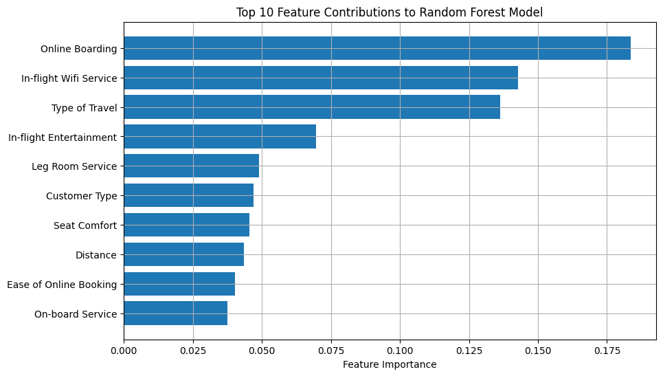

```python
feature_scores = pd.DataFrame({
    'Feature': x_train.columns,  # Assuming X is your feature matrix
    'Importance': model.feature_importances_
}).sort_values(by='Importance', ascending=False)

# Display the top 10 most important features
print(feature_scores.head(10))

# Plot the feature importance
plt.figure(figsize=(10, 6))
plt.barh(feature_scores['Feature'][:10][::-1], feature_scores['Importance'][:10][::-1])
plt.xlabel('Feature Importance')
plt.title('Top 10 Feature Contributions to Random Forest Model')
plt.grid(True)
plt.show()
```

### Conclusion:

The most influential features in this dataset are related to services provided during the flight, such as **Online Boarding**, **In-flight Wifi Service**, and **Type of Travel**, while attributes related to comfort and booking ease are of lesser importance.

# Model Evalution

## Confusion Matrix

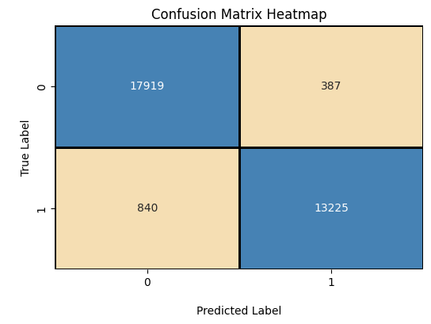

```python
cm = confusion_matrix(y_test, y_test_pred)
colors = ["#F5DEB3", "#4682B4"]
cmap = sns.color_palette(colors, as_cmap=True)

plt.figure(figsize=(6, 4))
sns.heatmap(cm, annot=True, fmt="d", cmap=cmap, cbar=False, linewidths=1, linecolor='black')
plt.xlabel("\nPredicted Label")
plt.ylabel("\nTrue Label")
plt.title("Confusion Matrix Heatmap")
plt.show()
```

### Observations

- **True Positives (TP)**: `13,225`  
  → Correctly predicted Satisfied responses.
- **True Negatives (TN)**: `17,919`  
  → Correctly predicted Neutral/Dissatisfied responses.
- **False Positives (FP)** **Type I Error** (False Positive): `387`  
  → Neutral/Dissatisfied predicted as Satisfied.
- **False Negatives (FN)** **Type II Error** (False Negative): `840`  
  → Satisfied predicted as Neutral/Dissatisfied.
- **Most predictions are correct** for both classes.
- **False negatives (840)** are higher than **false positives (387)**, meaning:
  - The model sometimes misses satisfied users, marking them as dissatisfied.
  - This may matter in contexts like customer feedback, where missing satisfied users could lead to unnecessary follow-up.
- **Overall**, the confusion matrix supports the strong metrics in the classification report (96% accuracy, high precision/recall).

## ROC Curve and AUC Score

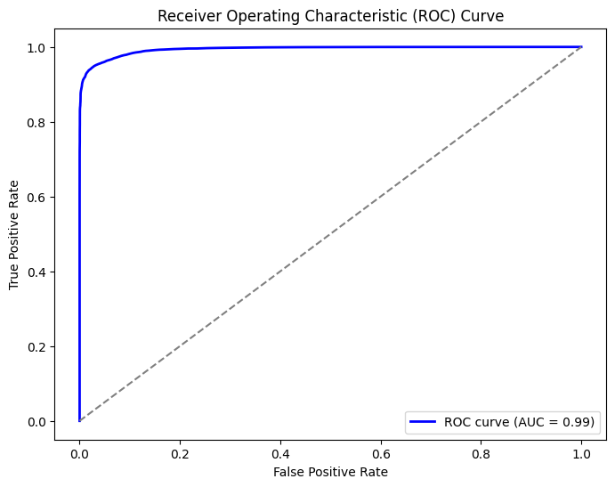

```python
y_true = y_test
y_pred_proba = model.predict_proba(x_test)[:, 1]

fpr, tpr, thresholds = roc_curve(y_true, y_pred_proba)


roc_auc = auc(fpr, tpr)



plt.figure(figsize=(8, 6))
plt.plot(fpr, tpr, color='b', lw=2, label='ROC curve (AUC = %0.2f)' % roc_auc)
plt.plot([0, 1], [0, 1], color='gray', linestyle='--')
plt.xlabel('False Positive Rate')
plt.ylabel('True Positive Rate')
plt.title('Receiver Operating Characteristic (ROC) Curve')
plt.legend(loc='lower right')
plt.show()
```

- **ROC Curve:** Visualizes the performance of a binary classifier by plotting the True Positive Rate (TPR) against the False Positive Rate (FPR) at various threshold settings.
- **Axes:**
  - Y-axis: **True Positive Rate (TPR)** or Sensitivity (Correctly identified positives / Total actual positives). Higher is better.
  - X-axis: **False Positive Rate (FPR)** (Incorrectly identified positives / Total actual negatives). Lower is better.
- **Ideal Curve:** A good model's ROC curve bends sharply towards the top-left corner (TPR=1, FPR=0).
- **Baseline:** The dashed diagonal line represents a random classifier (AUC = 0.5). A model should perform above this line.
- **AUC (Area Under the Curve):** A single metric summarizing performance across all thresholds.
  - Ranges from 0 (worst) to 1 (perfect).
  - 0.5 indicates random performance.
- **This Specific Curve:**
  - Shows **excellent performance** as the curve is very close to the top-left corner.
  - Has an **AUC of 0.99**, indicating outstanding ability to distinguish between the positive and negative classes.

## Classification Report

```python
print("Classification Report:\n", classification_report(y_test, y_pred))
```

```
Classification Report:
               precision    recall  f1-score   support

         0.0       0.96      0.98      0.97     18306
         1.0       0.97      0.94      0.96     14065

    accuracy                           0.96     32371
   macro avg       0.96      0.96      0.96     32371
weighted avg       0.96      0.96      0.96     32371
```

### Classification Report Summary

**Class Labels**:

- `0` → Neutral or Dissatisfied
- `1` → Satisfied
- **Precision**:
  - When the model predicts **Neutral or Dissatisfied (0)**, it's correct **96%** of the time.
  - When it predicts **Satisfied (1)**, it's correct **97%** of the time.  
    ➤ Very few false positives overall.
- **Recall**:
  - It correctly identifies **98%** of actual **Neutral/Dissatisfied** cases.
  - It correctly identifies **94%** of actual **Satisfied** cases.  
    ➤ Slightly more misses in detecting **Satisfied** responses.
- **F1-Score**:
  - Balanced performance for both classes: **0.97** for Neutral/Dissatisfied and **0.96** for Satisfied.  
    ➤ Strong balance between precision and recall.
- **Support**:
  - **18,306** samples of **Neutral/Dissatisfied**
  - **14,065** samples of **Satisfied**  
    ➤ Sufficient data for reliable evaluation.
- **Accuracy**:
  - The model correctly classified **96%** of the total 32,371 responses.
- **Macro Avg**:
  - Precision, recall, and F1-score are all **0.96**  
    ➤ Consistent performance across both satisfaction levels.
- **Weighted Avg**:
  - Metrics remain at **0.96** after accounting for the slight imbalance  
    ➤ Strong and reliable overall performance.